# Test of local structure optimization routines

Vera Kvisgaard

2024-05-22

This notes illustrates the usage of the `optimize_partition` routines for learning a partitioning of a CPT from data, and is intended to evaluate that these routines behave as expected.

```r
library(bida)
library(ggplot2)
here::i_am("./inst/rmd/optimize_partition.Rmd")
```

```
## here() starts at C:/Users/verak/OneDrive - Universitetet i Oslo/Documents/git/personal/bida
```

# Basic usage

The documentation of the function is found running `?bida::optimize_partition`. Here follows a few examples, where the optimization algorithms are applied to counts from a binary split, a v-structure and mixed cardinality setting.

### Binary split

First, design a frequency table `counts` representing a binary split and compare the output from the three optimization algorithms `tree`, `ldag` and `part`.

```r
levels <- rep(list(0:1), 2)
counts <- cbind(10, c(10, 10, 100, 100))
fits <- list()

# optimize partition over rows in the frequency table
fits$tree <- optimize_partition(counts, levels, ess = 1, "tree", regular = F, verbose = T)
fits$ldag <- optimize_partition(counts, levels, ess = 1, "ldag", regular = F, verbose = T)
fits$part <- optimize_partition(counts, levels, ess = 1, "part", regular = F, verbose = T)
```

```
##
## diff: 14.14454 Splitvariable: 2 Splitvalue: 0 1 Scores: -30.30853 -70.1786
## diff = 3.32932, node 1, context = 2, parts = 3,4, new partition: 1 2 3 3
## diff = 3.02486, node 1, context = 0, parts = 1,2, new partition: 2 2 1 1
## diff = 3.32932, parts = 3,4, new partition: 1 2 3 3
## diff = 3.02486, parts = 1,2, new partition: 2 2 1 1
```

```r
# compare counts and optimized partitions
parts  <- sapply(fits, function(x) get_parts(x$partition))
cbind(expand.grid(levels), counts, parts)

# print scores
sapply(fits, function(x) sum(x$scores))
```

```
##   Var1 Var2  1   2 tree ldag part
## 1    0    0 10  10    1    2    2
## 2    1    0 10  10    1    2    2
## 3    0    1 10 100    2    1    1
## 4    1    1 10 100    2    1    1
##      tree      ldag      part
## -100.4871 -100.4871 -100.4871
```

The `regular = TRUE` option of the `optimize_partition` function forces a partition that do not implicitly encode any conditional independencies.

```r
fits <- list()
fits$tree <- optimize_partition(counts, levels, ess = 1, "tree", regular = T, verbose = F)
fits$ldag <- optimize_partition(counts, levels, ess = 1, "ldag", regular = T, verbose = F)
fits$part <- optimize_partition(counts, levels, ess = 1, "part", regular = T, verbose = F)

# compare counts and optimized partitions
parts  <- sapply(fits, function(x) get_parts(x$partition))
cbind(expand.grid(levels), counts, parts)

# print scores
sapply(fits, function(x) sum(x$scores))
```

```
##   Var1 Var2  1   2 tree ldag part
## 1    0    0 10  10    1    1    1
## 2    1    0 10  10    2    2    2
## 3    0    1 10 100    3    3    3
## 4    1    1 10 100    4    3    3
##      tree      ldag      part
## -106.8413 -103.5120 -103.5120
```

### V-structure

While both the `tree` and `ldag` procedures can learn binary splits, `tree` can not learn v-structures.

```r
counts <- cbind(c(100, 10, 10, 10), c(10, 100, 100, 100))

# optimize partition over rows in the frequency table
fits <- list()
fits$tree <- optimize_partition(counts, levels, ess = 1, "tree", regular = F, verbose = F)
fits$ldag <- optimize_partition(counts, levels, ess = 1, "ldag", regular = F, verbose = F)
fits$part <- optimize_partition(counts, levels, ess = 1, "part", regular = F, verbose = F)

# compare counts and optimized partitions
parts  <- sapply(fits, function(x) get_parts(x$partition))
cbind(expand.grid(levels), counts, parts)

# print scores
sapply(fits, function(x) sum(x$scores))
```

```
##   Var1 Var2   1   2 tree ldag part
## 1    0    0 100  10    1    1    1
## 2    1    0  10 100    3    2    2
## 3    0    1  10 100    2    2    2
## 4    1    1  10 100    3    2    2
##      tree      ldag      part
## -143.6865 -140.4769 -140.4769
```

## Mixed cardinality

```r
levels <- list(0:1, 0:2)
counts <- cbind(1, rep(c(10, 100, 1000), each = 2))

# optimize partition over rows in the frequency table
fits <- list()
fits$tree <- optimize_partition(counts, levels, ess = 1, "tree", regular = F, verbose = T)
fits$ldag <- optimize_partition(counts, levels, ess = 1, "ldag", regular = F, verbose = T)
#fits$part <- optimize_partition(counts, levels, ess = 1, "part", regular = F, verbose = F)

# compare counts and optimized partitions
parts  <- sapply(fits, function(x) get_parts(x$partition))
cbind(expand.grid(levels), counts, parts)

# print scores
sapply(fits, function(x) sum(x$scores))
```

```
##
## diff: 3.94215 Splitvariable: 2 Splitvalue: 0 1 2 Scores: -8.938663 -13.85671 -18.83836
## diff = 2.54966, node 1, context = 4, parts = 5,6, new partition: 1 2 3 4 5 5
## diff = 2.54480, node 1, context = 2, parts = 3,4, new partition: 1 2 4 4 3 3
## diff = 2.49797, node 1, context = 0, parts = 1,2, new partition: 3 3 2 2 1 1  Var1 Var2 1    2 tree ldag
## 1    0    0 1   10    1    3
## 2    1    0 1   10    1    3
## 3    0    1 1  100    2    2
## 4    1    1 1  100    2    2
## 5    0    2 1 1000    3    1
## 6    1    2 1 1000    3    1
##      tree      ldag
## -41.63373 -41.63373
```

# Large sample size behaviour

This simulation experiment studies the large sample size behaviour of the optimization routines. Given a true partition `parts` of a parent space, the following code block implements the following simulation scheme:

1. Sample a CPT consistent with the partition `parts`
2. For each sample size, sample the outcome variable from that CPT. The parent outcomes are assumed uniformily distributed.
3. Learn a partition from the data and compare with the true partition. A paired-confusion matrix is used to evaluate the learned and true partition.

```r
run <- function(parts, levels, r, alpha = rep(1, r), verbose = F, doPlot = T) {
  # simulation: learn partitions from data
  # parts = partitioning of parent space
  # levels = levels of the parent variables
  # r: cardinality of outcome variable
  # alpha: hyperparam for Dirichlet distrib over each conditional prob vector

  # relab parts from 1, 2, .., nparts
  uparts <- unique(parts)
  nparts <- length(uparts)
  parts  <- match(parts, uparts)
  q <- length(parts)

  # specify simparams and init array for storing results
  simpar <- list(rep = 1:5,
                 N = round(10**seq(2, 4, length.out = 11)),
                 struct = c("tree", "ldag"),
                 regular = c(TRUE, FALSE))
  res <- array(list(), lengths(simpar), simpar)

  for (i in simpar$rep) {

    # draw reduced CPT
    set.seed(i)
    cpt <- vapply(1:nparts, function(x) bida:::rDirichlet(1, alpha), numeric(r))

    for (j in seq_along(simpar$N)) {

      N <- simpar$N[[j]]


      # sample from conditional distribution
      set.seed(j)
      par <- sample.int(q, N, replace = T) # sample parents uniformily
      x   <- bida:::sample_from_cpt(cpt, parts[par]-1, r)
      # check means
      tab <- table(parts[par], x)
      tab/rowSums(tab)-t(cpt)


      # compute frequency table
      tab  <- as.matrix(table(par, x))

      for (k in seq_along(simpar$struct)) {
        for (l in seq_along(simpar$regular)){
          struct <- simpar$struct[k]
          regular <- simpar$regular[l]
          if (verbose) cat("\nOptimize.", N, struct, regular)
          # optimize local structure
          fit <- bida:::optimize_partition(tab, levels, 1, struct, regular = regular, verbose = verbose)

          # compute partition similarity
          tmp <- get_parts(fit$partition)
          res[[i, j, k, l]] <- compute_paired_confusion_matrix(tmp, parts)

          # compute MSE of point-estimates

        }
      }
    }
  }

  # collect results in data.frame
  df <- cbind(expand.grid(simpar), do.call(rbind, res))
  plots <- list()

  if (doPlot) {
    # F-measure
    plot <- ggplot(df, aes(N, y = 2*a/(2*a+b+c),  group = rep)) +
                  facet_grid(. ~ struct + regular) +
                  geom_line() +
                  scale_x_log10()
    plots$Fmeasure <- plot

    # decomp paired comparisons
    df_long <- tidyr::pivot_longer(df, letters[1:4])
    plot <- ggplot(df_long, aes(N, value, fill = name)) +
              facet_grid(rep ~ struct + regular) +
              geom_col() +
              scale_x_log10()
    plots$compar <- plot

  }
  return(list(df = df, plots = plots))
}


compute_paired_confusion_matrix <- function(x, y) {
  stopifnot(length(x) == length(y))
  n <- length(x)
  res <- matrix(NA, n, n)
  for (i in seq(n)[-n]) {
    for (j in seq(i+1, n)) {
      #cat("\n", i, j, x[i], x[j], y[i], y[j])
      if (x[i] == x[j]) {
        if (y[i] == y[j]) {
          res[i, j] <- "a"
        } else {
          res[i, j] <- "b"
        }
      } else if (y[i] == y[j]) {
        res[i, j] <- "c"
      } else {
        res[i, j] <- "d"
      }
    }
  }
  table(factor(res, letters[1:4]))
}
```

## Binary split over two binary parents

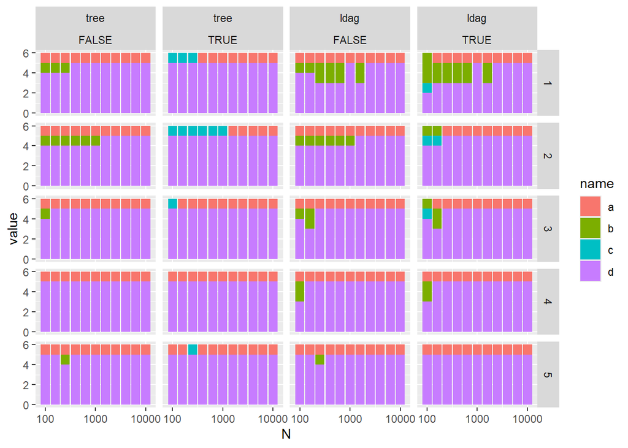

```
##   Var1 Var2 parts
## 1    0    0     1
## 2    1    0     1
## 3    0    1     3
## 4    1    1     4
```

```r
levels <- list(0:1, 0:1)
labels <- list(rbind(0), NULL)
parts  <- bida:::labels_to_parts(labels, lengths(levels), levels)

# print partition
cbind(expand.grid(levels), parts)

# run simulation
res <- run(parts, levels, r = 2, verbose = F)
res$plots$compar
```

## Vstructure over two binary parents

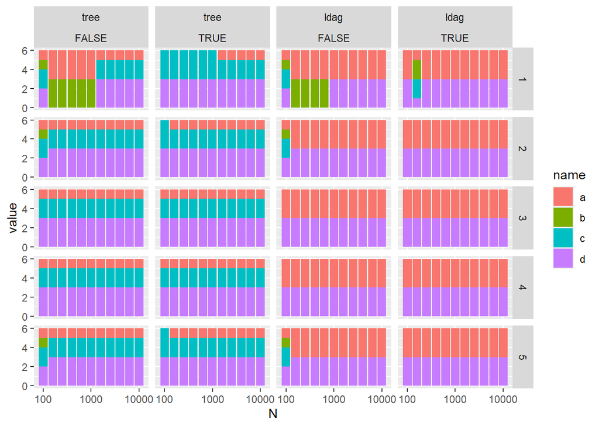

```
##   Var1 Var2 parts
## 1    0    0     1
## 2    1    0     1
## 3    0    1     1
## 4    1    1     4
```

```r
levels <- list(0:1, 0:1)
labels <- list(rbind(0), rbind(0))
parts  <- bida:::labels_to_parts(labels, lengths(levels), levels)

# print partition
cbind(expand.grid(levels), parts)

# run simulation
res <- run(parts, levels, r = 2, verbose = F)
res$plots$compar
```

## Three binary parents

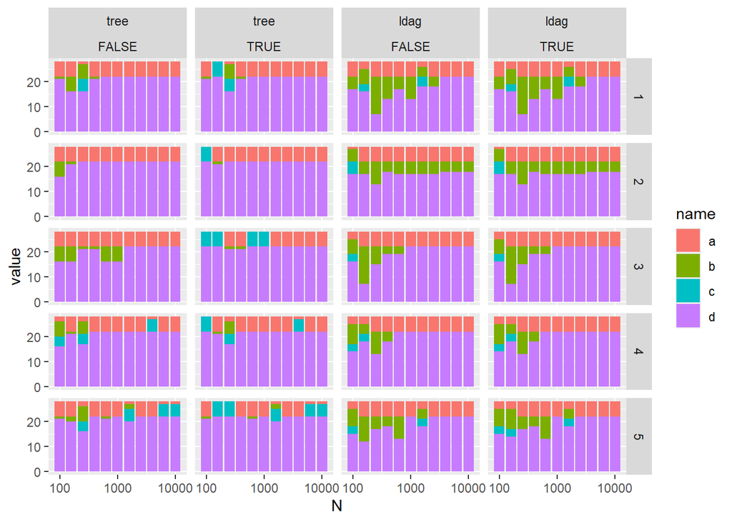

```
##   Var1 Var2 Var3 parts
## 1    0    0    0     1
## 2    1    0    0     1
## 3    0    1    0     1
## 4    1    1    0     1
## 5    0    0    1     5
## 6    1    0    1     6
## 7    0    1    1     7
## 8    1    1    1     8
```

```r
levels <- list(0:1, 0:1, 0:1)
labels <- list(rbind(c(0, 0), c(1, 0)),
               rbind(c(0, 0), c(1, 0)),
               NULL)
parts  <- bida:::labels_to_parts(labels, lengths(levels), levels)

# print partition
cbind(expand.grid(levels), parts)

# run simulation
res <- run(parts, levels, r = 2, verbose = F)
res$plots$compar
```

## Mixed cardinality

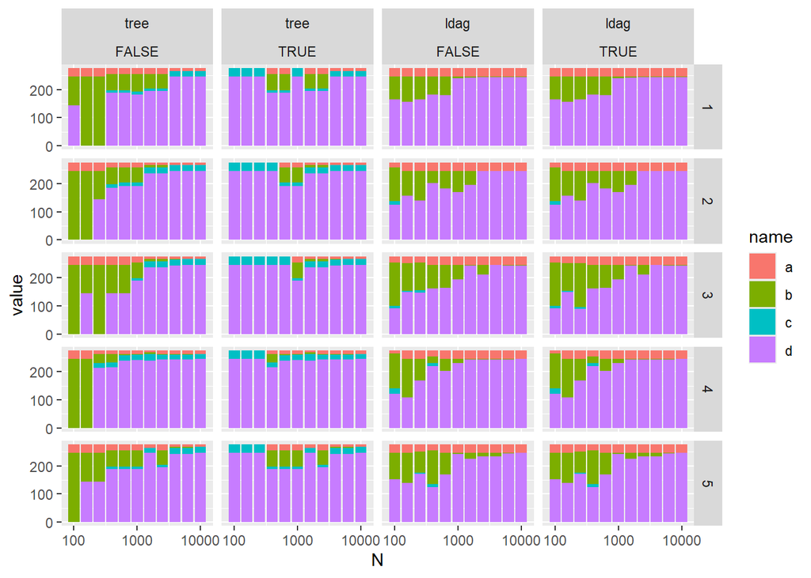

```
##    Var1 Var2 Var3 parts
## 1     0    0    0     1
## 2     1    0    0     2
## 3     0    1    0     1
## 4     1    1    0     2
## 5     0    2    0     1
## 6     1    2    0     2
## 7     0    0    1     1
## 8     1    0    1     2
## 9     0    1    1     9
## 10    1    1    1    10
## 11    0    2    1    11
## 12    1    2    1    12
## 13    0    0    2     1
## 14    1    0    2     2
## 15    0    1    2    15
## 16    1    1    2    16
## 17    0    2    2    17
## 18    1    2    2    18
## 19    0    0    3     1
## 20    1    0    3     2
## 21    0    1    3    21
## 22    1    1    3    22
## 23    0    2    3    23
## 24    1    2    3    24
```

```r
levels <- list(0:1, 0:2, 0:3)
labels <- list(NULL,
               rbind(c(0, 0), c(1, 0)),
               rbind(c(0, 0), c(1, 0)))
parts  <- bida:::labels_to_parts(labels, lengths(levels), levels)

# print partition
cbind(expand.grid(levels), parts)

# run simulation
res <- run(parts, levels, r = 3, verbose = F)
res$plots$compar
```